# The German Credit Data

Manunpat Sirijaturaporn and Arturo García Luna Beltrán

02 junio, 2022

## **Introduction**

Our motivation on choosing the German Credit data is mainly because we think that this type of exercise will enhance our skills as business analysts for a proper decision making.

The German Credit data has data on 1000 past credit applicants, described by 30 variables. Each applicant is rated as “Good” or “Bad” credit (encoded as 1 and 0 respectively in the response variable). We want to obtain a model that may be used to determine if new applicants present a good or bad credit risk.

## **EDA**

### **Missing values**

```
##   rows columns discrete_columns continuous_columns all_missing_columns
## 1 1000      30                0                 30                   0
##   total_missing_values complete_rows total_observations memory_usage
## 1                    0          1000              30000       126872
```

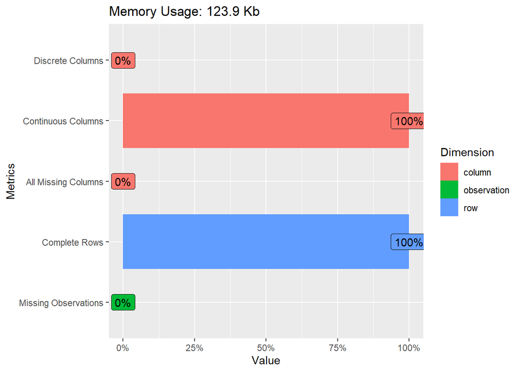

```
## [1] 0
```

```
## [1] 1
```

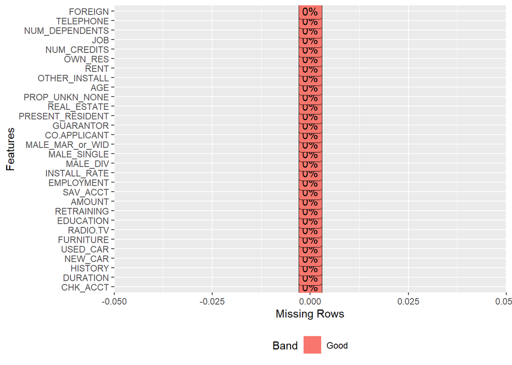

### **Overall Summary**

> **Findings during the Exploratory data analysis**
- Response Variable: has 70% good applicants and 30% bad applicants.
- Duration: the average duration of credit in months is 20.9 months whereas the first and third quartiles are 12 and 24 months.
- History: something important to mention on the credit history is that there is 29% of critical accounts.
- Variables considered as Purposes of credit:
  - New Car: 23% of users
  - Used Car: 10% of users
  - Furniture: 18% of users
  - Radio / TV: 28% of users
  - Education: 5% of users
  - Retraining: ~ 10% of users
  - There is a 6% of users that we don’t know the purpose of the credit
- Gender and status of applicants:
  - 5% are male and divorced
  - 55% are male and single
  - 9% are male and married/a widower
  - 31% of the others such as women in any status

**German Credit Data Summary**

| **Variables** | **N** | **Customers**, N = 1,000<sup>1</sup> |
| --- | --- | --- |
| CHK_ACCT | 1,000 |  |
| < 0DM |  | 274, (27%) |
| >= 200DM |  | 63, (6.3%) |
| 0 < -- < 200DM |  | 269, (27%) |
| No checking account |  | 394, (39%) |
| DURATION | 1,000 |  |
| Median, (IQR) |  | 18, (12, 24) |
| Mean, (Range) |  | 21, (4, 72) |
| HISTORY | 1,000 |  |
| All credits at this bank paid back dully |  | 49, (4.9%) |
| Critical account |  | 293, (29%) |
| Existing credits paid |  | 530, (53%) |
| No checking account |  | 88, (8.8%) |
| No credit data |  | 40, (4.0%) |
| AMOUNT | 1,000 |  |
| Median, (IQR) |  | 2,320, (1,366, 3,972) |
| Mean, (Range) |  | 3,271, (250, 18,424) |
| SAV_ACCT | 1,000 |  |
| < 100DM |  | 603, (60%) |
| >= 1000DM |  | 48, (4.8%) |
| 100 <= -- < 500DM |  | 103, (10%) |
| 500 <= -- < 1000DM |  | 63, (6.3%) |
| Unknown/No savings account |  | 183, (18%) |
| EMPLOYMENT | 1,000 |  |
| < 1 year |  | 172, (17%) |
| >= 7 years |  | 253, (25%) |
| 1 <= -- < 4 years |  | 339, (34%) |
| 1 <= -- < 7 years |  | 174, (17%) |
| Unemployed |  | 62, (6.2%) |
| INSTALL_RATE | 1,000 |  |
| 1 |  | 136, (14%) |
| 2 |  | 231, (23%) |
| 3 |  | 157, (16%) |
| 4 |  | 476, (48%) |
| PRESENT_RESIDENT | 1,000 |  |
| < 1 year |  | 130, (13%) |
| >= 4 years |  | 413, (41%) |
| 1 <= -- < 2 years |  | 308, (31%) |
| 2 <= -- < 3 years |  | 149, (15%) |
| AGE | 1,000 |  |
| Median, (IQR) |  | 33, (27, 42) |
| Mean, (Range) |  | 36, (19, 125) |
| NUM_CREDITS | 1,000 |  |
| 1 |  | 633, (63%) |
| 2 |  | 333, (33%) |
| 3 |  | 28, (2.8%) |
| 4 |  | 6, (0.6%) |
| JOB | 1,000 |  |
| Management/self-employed/highly qualified employee/officcer |  | 148, (15%) |
| Skilled employee/official |  | 630, (63%) |
| Unemployed/unskilled non-resident |  | 22, (2.2%) |
| Unskilled - resident |  | 200, (20%) |
| NUM_DEPENDENTS | 1,000 |  |
| 1 |  | 845, (84%) |
| 2 |  | 155, (16%) |
| NEW_CAR, Positive(Yes) | 1,000 | 234, (23%) |
| USED_CAR, Positive(Yes) | 1,000 | 103, (10%) |
| FURNITURE, Positive(Yes) | 1,000 | 181, (18%) |
| RADIO.TV, Positive(Yes) | 1,000 | 280, (28%) |
| EDUCATION, Positive(Yes) | 1,000 |  |
| Binary as -1 (OBS #37) |  | 1, (0.1%) |
| No |  | 950, (95%) |
| Yes |  | 49, (4.9%) |
| RETRAINING, Positive(Yes) | 1,000 | 97, (9.7%) |
| MALE_DIV, Positive(Yes) | 1,000 | 50, (5.0%) |
| MALE_SINGLE, Positive(Yes) | 1,000 | 548, (55%) |
| MALE_MAR_or_WID, Positive(Yes) | 1,000 | 92, (9.2%) |
| CO.APPLICANT, Positive(Yes) | 1,000 | 41, (4.1%) |
| GUARANTOR, Positive(Yes) | 1,000 |  |
| Binary as 2 (OBS #234) |  | 1, (0.1%) |
| No |  | 948, (95%) |
| Yes |  | 51, (5.1%) |
| REAL_ESTATE, Positive(Yes) | 1,000 | 282, (28%) |
| PROP_UNKN_NONE, Positive(Yes) | 1,000 | 154, (15%) |
| OTHER_INSTALL, Positive(Yes) | 1,000 | 186, (19%) |
| RENT, Positive(Yes) | 1,000 | 179, (18%) |
| OWN_RES, Positive(Yes) | 1,000 | 713, (71%) |
| TELEPHONE, Positive(Yes) | 1,000 | 404, (40%) |
| FOREIGN,, Positive(Yes) | 1,000 | 37, (3.7%) |
| RESPONSE | 1,000 | 700, (70%) |

<sup>1</sup> n, (%)

### **Histogram to visualize numerical and categorical variables**

Histogram is to summarize the distribution of the data set thus binary variables are not included in the chart which have only 0 and 1 values.

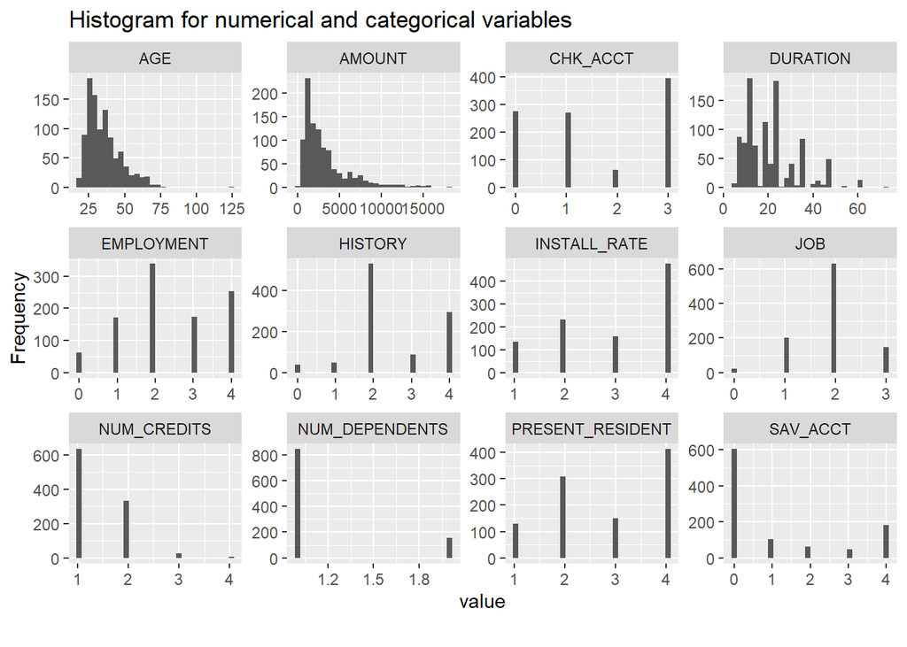

- AGE, AMOUNT and DURATION: positive skewness meaning that the bank may expect frequent young clients which borrow small loan with approximately 0-25 months credit duration and a few elderly clients which borrow large loan with longer credit duration.
- The most frequent category for CHK_ACCT is no checking account and only a few applicants have more than 200 DM. Majority of applicants have less than 100 DM in saving account.
- Most applicants are employed with the skilled employee category. The most highest frequency is in the 1-4 years category.
- The most common installment rate is 4% of disposable income and the most common number of existing credits at this bank is 1. Also, the larger parts of applicants are individuals for whom liable to provide maintenance. In general, applicants have been in the current residence for more than 1 year.
- Most of the applicants are paid the existing credits back duly however, the second most frequent group is the critical account.

### **Box plot to interpret numerical data**

We use box plot to visualize quartile, median, skewness and outliers of numerical data. Thus, in this section, we select only DURATION, AMOUNT, INSTALL_RATE, AGE, NUM_CREDITS and NUM_DEPENDENTS. However, we also include EMPLOYMENT and PRESENT_RESIDENT. Although both are categorical variables, the values represent the length of employment and residency.

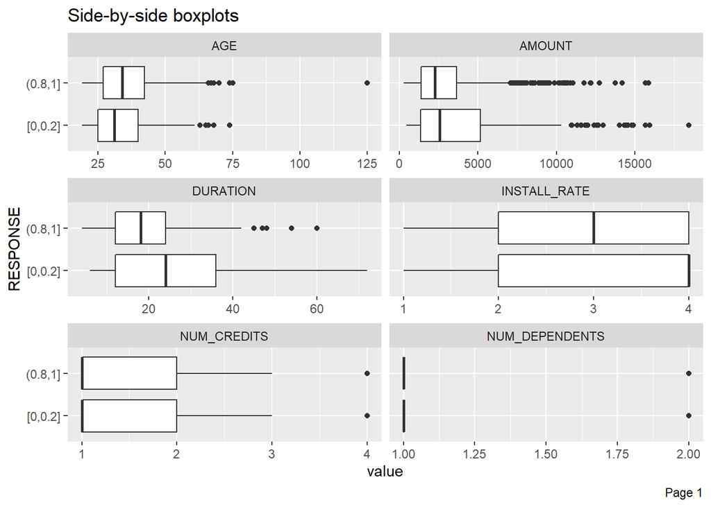

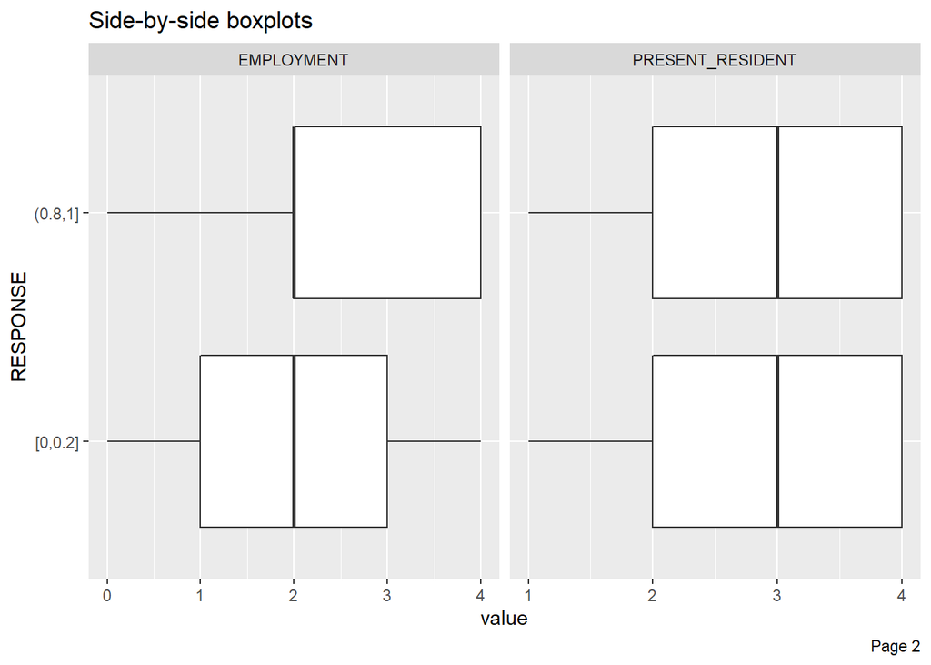

Regarding the ‘good’ applicants from box plot, they tend to have one of the following characteristics: shorter credit duration, longer employment duration, lower credit amount. Regarding the AGE variable, the age profiles of good applicants tend to be slightly higher. Also, we spot a possible error which is 125 years old. As for the rest variables, INSTALL_RATE, NUM_CREDITS, NUM_DEPENDENTS and PRESENT_RESIDENT, there are no significant differences between good and bad applicants.

> **Errors Found and Modification**
- EDUCATION: is a binary variable (0/1) but we notice from the description table that minimum value is -1 (observation number 37).
- GUARANTOR: is a binary variable (0/1) but we notice from the description table that maximum value is 2 (observation number 234).
- AGE: we spotted 125 years (the observation number 537).
- PRESENT_RESIDENT: is a categorical data and we spotted that it contains 0 to 3 in in the pdf data description; however, it contains 1 to 4 in the actual data.  
  Therefore, we believe that these numbers are errors on the data, so we modify them from the `german_credit table` as following:
  - EDUCATION at the observation number 37 is modified from -1 to 1
  - GUARANTOR at the observation number 234 is modified from 2 to 1
  - AGE at the observation 537 is modified from 125 to 75

### **Summary by RESPONSE**

We select to show mean in this case which is more appropriate than median since our data contains many binary variables

```
##                       0       1
## DURATION          24.86   19.21
## AMOUNT          3938.13 2985.46
## INSTALL_RATE       3.10    2.92
## AGE               33.96   36.22
## NUM_CREDITS        1.37    1.42
## NUM_DEPENDENTS     1.15    1.16
## NEW_CAR            0.30    0.21
## USED_CAR           0.06    0.12
## FURNITURE          0.19    0.18
## RADIO.TV           0.21    0.31
## EDUCATION          0.07    0.04
## RETRAINING         0.11    0.09
## MALE_DIV           0.07    0.04
## MALE_SINGLE        0.49    0.57
## MALE_MAR_or_WID    0.08    0.10
## CO.APPLICANT       0.06    0.03
## GUARANTOR          0.03    0.06
## REAL_ESTATE        0.20    0.32
## PROP_UNKN_NONE     0.22    0.12
## OTHER_INSTALL      0.25    0.16
## RENT               0.23    0.16
## OWN_RES            0.62    0.75
## TELEPHONE          0.38    0.42
## FOREIGN            0.01    0.05
```

We can see that around 31% and 21% of total ‘Good’ credit used for radio/TV and new cars respectively while approximately 30% and 21% of ‘Bad’ credit used for new cars and radio/TV respectively.

### **Scatter plots and Correlations**

We can ignore correlations between categorical and binary variables.

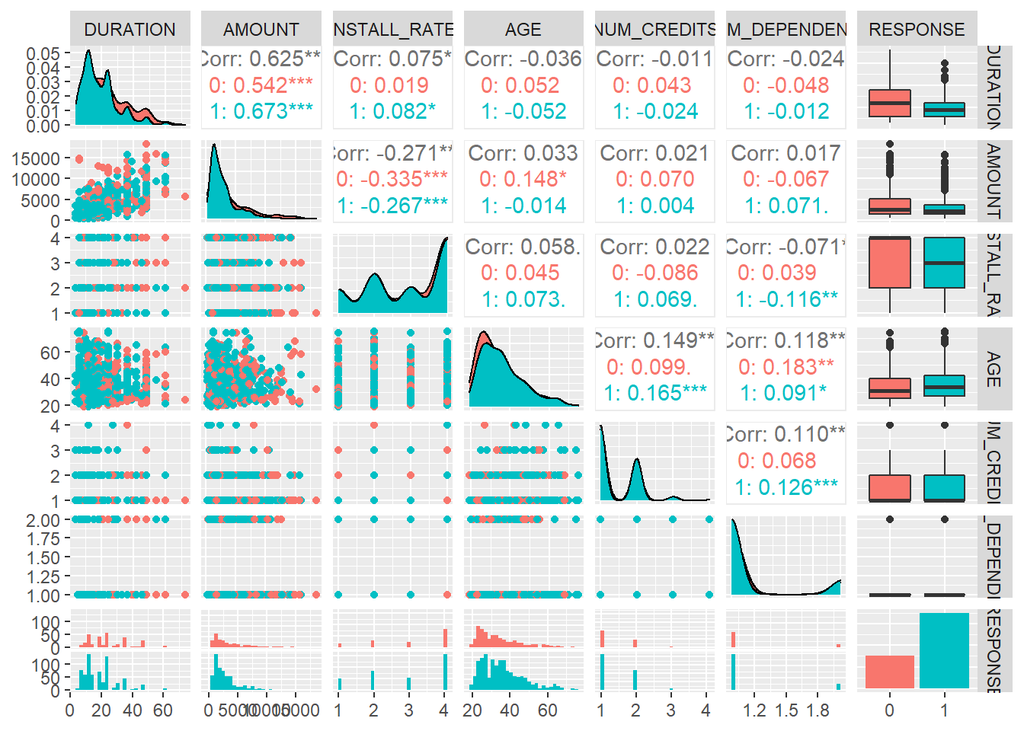

From the result, we see that AMOUNT and DURATION are correlated.

## **Analysis**

### **Data Preparation for Models**

Before starting applying the models to the data, first we started converting the categorical variables from numeric(int) values to categorical (factor). For example, CHK_ACCT is actually a categorical data but the values in german_credit are numeric (int). On the following pie chart we can observe this transformation.

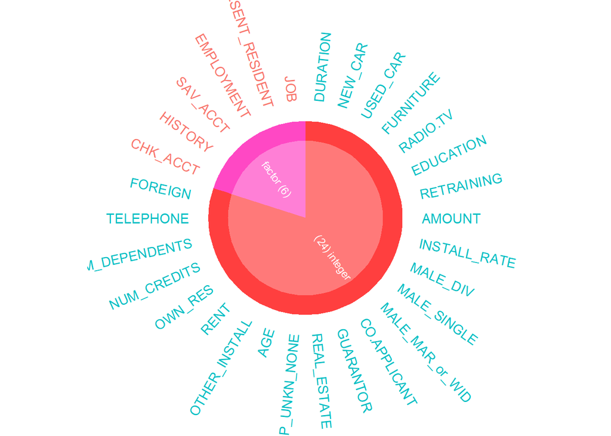

Only for our `RESPONSE` variable, we transform the values to “Good” if it is equal to 1, and “Bad” otherwise. We allocated this new values in a column called `Applicant`. It is worth mentioning that we could have treated the data the way it was “0 & 1”, and applied a regression task, but we preferred to visualize the data with good and bad values.

Second, we set a seed value for reproducibility purposes for the data partitioning.

Finally, we proceed splitting the German Credit data into two datasets, to ensure that the models will not overfit the data and that the results of the predictions are good. To do so, we select for the first set; our **training set**, 80% of the observations randomly(*800 obs*), and for the observations that remain we took them as our **test set**(*200 obs*).

### **Models**

Our goal is to obtain a model that may be used to determine if new applicants present a good or bad credit risk. Since we have transformed the column `RESPONSE` as a factor with categorical values, we will apply models that consider a classification task.

We have chosen the models as follows:

1. Decision Trees
2. Random Forest
3. Logistic Regression
4. Neural Networks

### **Decision Trees - Classification**

Decision trees are algorithms that recursively search the space for the best boundary possible, until we unable them to do so (Ivo Bernardo,2021). The basic functionality of decision trees is to split the data space into rectangles, by measuring each split. The main goal is to minimize the impurity of each split from the previous one.

> **Build the model** - Unbalanced data without Cross validation

After creating the model with `rpart` function, we proceed to plot it to visualize the result of this classification tree. In the graph we can observe that the main splitting variable is “CHK_ACCT = 0,1” the selected one, it reduces the impurity by **43.99**. In addition, we can determine which variables have the most significant reduction impact on the impurity function; in this case they will be those with the longest splitting length.

- The variables are:
  - HISTORY: Credit **History**
  - DURATION: **Duration** of the Credit

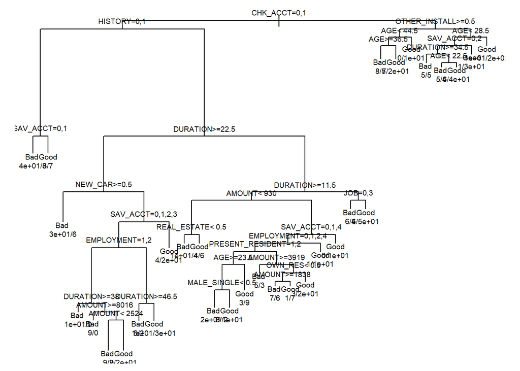

> **Pruning the Tree**

We decided to prune the tree to reduce the statistical noise in the data, because as the tree splits over and over the length becomes shorter, therefore the importance of the split diminishes. Another reason is that since decision trees are susceptible to overfitting, reducing the size of the model will improve the accuracy.

```
##
## Classification tree:
## rpart(formula = Applicant ~ ., data = df.tr, method = "class",
##     model = TRUE, cp = 0.001)
##
## Variables actually used in tree construction:
##  [1] AGE              AMOUNT           CHK_ACCT         DURATION
##  [5] EMPLOYMENT       HISTORY          JOB              MALE_SINGLE
##  [9] NEW_CAR          OTHER_INSTALL    OWN_RES          PRESENT_RESIDENT
## [13] REAL_ESTATE      SAV_ACCT
##
## Root node error: 240/800 = 0.3
##
## n= 800
##
##           CP nsplit rel error  xerror     xstd
## 1  0.0520833      0   1.00000 1.00000 0.054006
## 2  0.0361111      3   0.84167 0.94583 0.053129
## 3  0.0166667      6   0.73333 0.85417 0.051449
## 4  0.0111111     10   0.66667 0.82083 0.050773
## 5  0.0093750     13   0.63333 0.81250 0.050599
## 6  0.0083333     18   0.57917 0.84583 0.051284
## 7  0.0041667     21   0.55417 0.85000 0.051367
## 8  0.0020833     24   0.54167 0.81667 0.050686
## 9  0.0010417     26   0.53750 0.85833 0.051531
## 10 0.0010000     30   0.53333 0.86667 0.051694
```

Another way to find the lowest-cross-validated rate is by visualizing the size of the tree on a plot, in which you can observe the relative error `rel error` on the y axis, the cross-validation procedure `cp` on the x axis, and on the top side of the plot,the size of the tree (no. of terminal nodes). The black line is the cross-validated error rate `xerror` of each split.

From the graph, we can visualize right away which cp to choose we can select the one closest to the dotted line, and the simplest one. For this case we could choose the tree with 7 nodes with a cp of 0.025

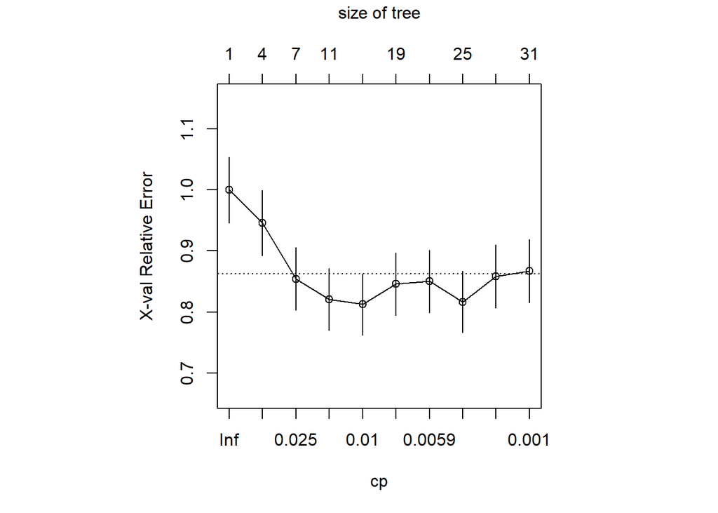

To visualize how the classification tree will look-like after the pruning, we plot it again. *Note: On the following tree we considered the cp of* **0.0166667**.

We can note from the graph that the classification tree has shortened, and the main splitting branch variable remains the same as expected, but the third node `OTHER_INSTALL` that was considered on the previous tree, has been removed, the same happened with the fourth node `SAV_ACCT` and the node `JOB`.

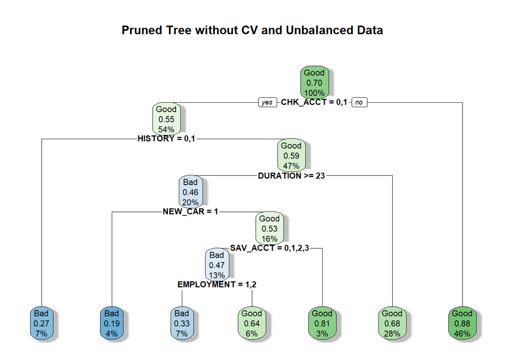

> **Model evaluation** - Unbalanced data without Cross validation

```
##
##  Bad Good
##  240  560
```

First,we want to measure the accuracy of our model with the unbalance data, to know how good our model is, so we compute the confusion matrix to observe it’s values.

```
##       Obs
## Pred   Bad Good
##   Bad   21   13
##   Good  39  127
```

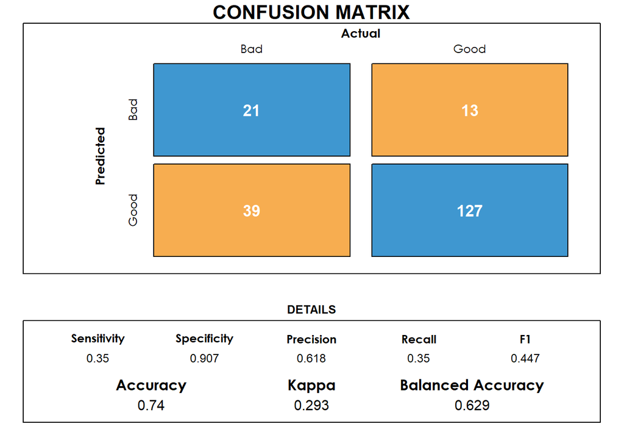

> **Class Balancing** - Re-sampling Data

Balancing by re-sampling consists of increasing the number of cases in the smallest class (here “Bad”) by re-sampling at random cases from this category to get the same amount as the largest category (here “Good”). It has the same aim as sub-sampling which is to have the same amount on each category(reducing the highest category).

After applying the re-sampling we balance the data set to 560 applicants each.

```
##
##  Bad Good
##  560  560
```

> **Model evaluation** - Balanced data with Cross validation

On the previous analysis we have seen how to build a decision tree model with the `rpart` function(by hand), also how to select manually the preferred CP from the complexity table, and how to identify it on a graph. Now, we will build a decision tree model with a Cross validation (CV) with the `caret`function (automatically), it will be applied to the balanced data that we created on the previous point. Finally, we will compare which balance accuracy is the highest.

First, we split the **training data** into 10 non-overlapping subsets, 9/10 of this folds will be used to train the model, and 1/10 will be used as a validation set. Secondly, we build the model with the data that we have already split to the function trainControl of `caret`, and plot the tree with the final Model computed.

Finally, we apply the model to the test data set to visualize the outcome on the confusion matrix table.

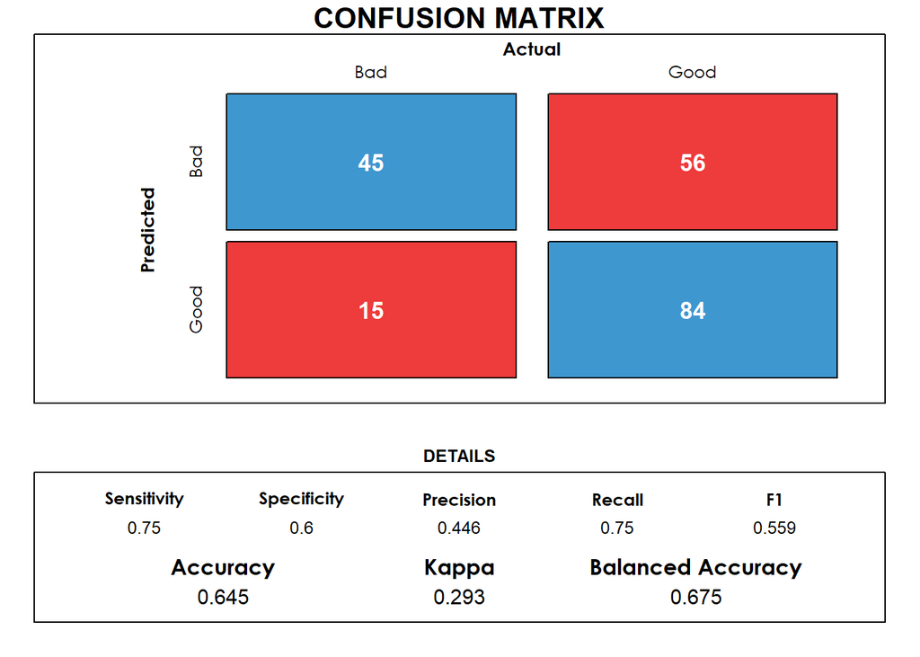

Overall, we determine that the model computed with the `caret`function was the one performing better on new data (*test set*) for the Classification Tree. Moreover, as we wanted to visualize the best result of the classification tree, we plot it into a graph.

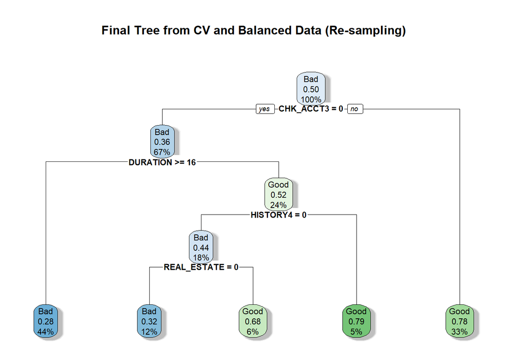

We can recognize that the variables selected for the final output by order of importance were:

- CHK ACCT
- Duration
- History
- Real Estate

### **Random Forest**

Random Forest (RF) are algorithms of a set of decision trees that will produce a final prediction with the average outcome of the set of trees considered (*user can define the amount of trees and the number of variables for each node*). One of the reasons that we decided to test this method is because RF are considered to be more stable than Decision Trees; more trees better performance, but certain advantages come at a price. RF slow down the computation speed and cannot be visualize, however, we will look at the results for later comparison (Saikumar Talari, 2022).

> **Model evaluation** - Balanced data with Cross validation

For this method we will consider the same approach as the last one of Classification Tree, but we will use another class balancing called Sub-sampling. Balancing by sub-sampling consists of decreasing the number of cases in the highest class (here “Good”) by sub-sampling at random cases from this category to get the same amount as the smallest category (here “Bad”). It has the same aim as re-sampling which is to have the same amount on each category(*increasing the lowest category*). Finally, we will also take into account a Cross-Validation technique.

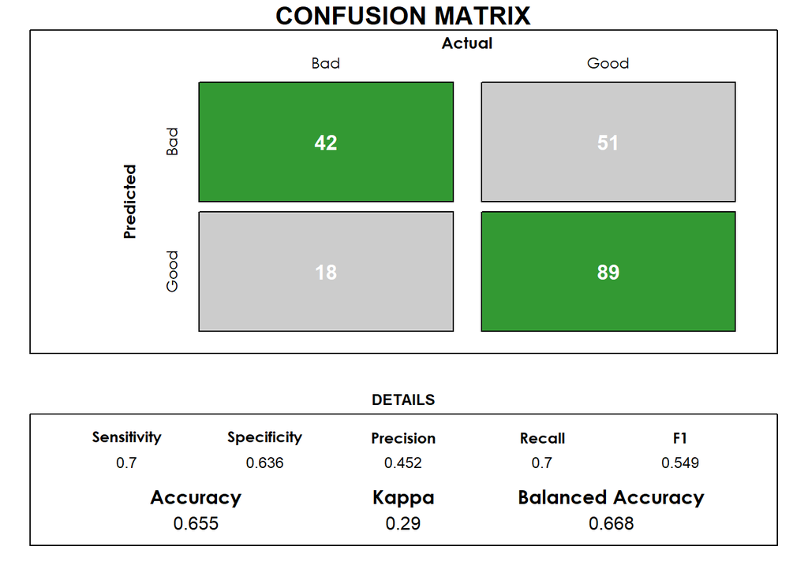